# machine-learning-linearregression

Explanation:

pandas as pd Used for data manipulation and analysis. It provides data structures like DataFrame and functions for cleaning and transforming data.

numpy as np Fundamental package for numerical computing in Python. It provides support for arrays, mathematical functions, and linear algebra.

matplotlib.pyplot as plt Used for data visualization. It offers functions to create line plots, scatter plots, histograms, and more.

from sklearn import linear_model Imports Scikit-learn’s linear modeling tools, including models like LinearRegression, LogisticRegression, and others. These are used for performing both regression and classification tasks.

```python
import pandas as pd
import numpy as np
import matplotlib.pyplot as plt
from sklearn import linear_model
```

# Creating a Simple Housing Dataset

```python
data = pd.DataFrame({'area': [2600,3000,3200,3600,4000],
       'price': [550000, 565000,610000,680000,725000]
       })
data
```

|  | area | price |
| --- | --- | --- |
| 0 | 2600 | 550000 |
| 1 | 3000 | 565000 |
| 2 | 3200 | 610000 |
| 3 | 3600 | 680000 |
| 4 | 4000 | 725000 |

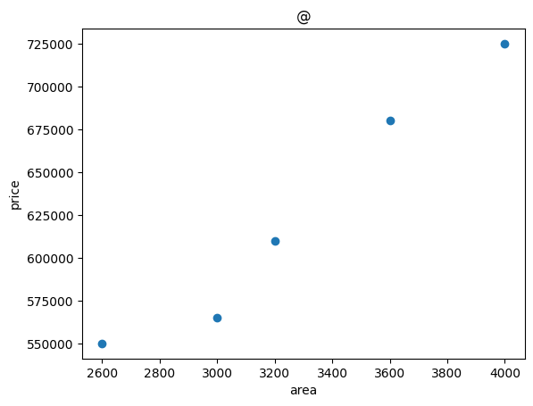

```python
plt.scatter(data.area, data.price)
plt.xlabel('area')
plt.ylabel('price')
plt.title('@')
plt.show()
```

Training a Linear Regression Model.

LinearRegression(): Creates a linear regression model from Scikit-learn’s linear_model module. This model finds the best-fit line that predicts price based on area.

```python
reg = linear_model.LinearRegression()
reg.fit(data[['area']],data.price)
```

```
LinearRegression()
```

This uses the trained linear regression model to predict the price of a house with an area of 3300 square feet.

```python
predicted_price=reg.predict([[3300]])
print(f"Predicted price for 3300 sq ft: ${predicted_price[0]:,.2f}")
```

```
Predicted price for 3300 sq ft: $628,715.75
```

Getting the Slope (Coefficient) of the Linear Model. Explanation:

This returns the coefficient (also called the slope) of the trained linear regression model.

In this context, it represents the estimated change in price per additional square foot of house area.

For every additional 1 square foot of area, the predicted house price increases by approximately $135.79.

```python
reg.coef_

print(f"Price increases by ${reg.coef_[0]:,.2f} per additional sq ft")
```

```
Price increases by $135.79 per additional sq ft
```

Explanation:

This returns the intercept of the trained linear regression model.

It represents the predicted price when the area is 0 square feet.

In the equation of a line:

```python
reg.intercept_
```

```
180616.43835616432
```

# m=coef, b=intercept, mx+b

```python
135.78767123*3300+180616.43835616432
```

```
628715.7534151643
```

```python
predicted_price = reg.predict([[5000]])
print(f"Predicted price for 5000 sq ft: ${predicted_price[0]:,.2f}")
```

```
Predicted price for 5000 sq ft: $859,554.79
```

## Pandas Dataframe

```python
d = pd.DataFrame({
    'area': [1000,1500,2300,3540,4120,4560,5490,3460,4750,2300,9000,8600,7100]
})
d
```

|  | area |
| --- | --- |
| 0 | 1000 |
| 1 | 1500 |
| 2 | 2300 |
| 3 | 3540 |
| 4 | 4120 |
| 5 | 4560 |
| 6 | 5490 |
| 7 | 3460 |
| 8 | 4750 |
| 9 | 2300 |
| 10 | 9000 |
| 11 | 8600 |
| 12 | 7100 |

## Predicting House Prices for Multiple Areas

Explanation:

This uses the trained linear regression model (reg) to predict house prices for all the values in the d['area'] column.

The result, p, is a NumPy array of predicted prices that corresponds to each house size in d.

```python
p = reg.predict(d)
```

### Adding Predicted Prices to the DataFrame

Explanation:

This line adds a new column called 'prices' to the DataFrame d.

It assigns the predicted house prices (from the model) to each corresponding house area.

```python
d['prices'] = p
```

This will convert the prices column to a string with two decimal places

x is the argument (each value in the prices column).

f"${x:,.2f}" is the expression that formats the value x as a string.

f"${x:,.2f}" Formatting: This part is using f-string formatting (formatted string literals), which is a way to embed expressions inside string literals. The format inside the curly braces {} defines how x should be displayed.

$: This adds the dollar sign at the start of the formatted string.

x: The value of x (the price) is what you are formatting.

:: The colon (:) starts the formatting specifiers.

**,**: The comma adds a thousands separator, which is commonly used in numbers to make them more readable (e.g., 1,000instead of1000`).

.2f:

.2 specifies the number of decimal places you want to display. In this case, it's 2 decimal places (e.g., 316404.11).

f stands for floating-point number. It tells Python to format the number as a float, meaning you want to show decimal places.

```python
d['prices'] = d['prices'].apply(lambda x: f"${x:,.2f}")
print(d)
```

```
    area         prices
0   1000    $316,404.11
1   1500    $384,297.95
2   2300    $492,928.08
3   3540    $661,304.79
4   4120    $740,061.64
5   4560    $799,808.22
6   5490    $926,090.75
7   3460    $650,441.78
8   4750    $825,607.88
9   2300    $492,928.08
10  9000  $1,402,705.48
11  8600  $1,348,390.41
12  7100  $1,144,708.90
```

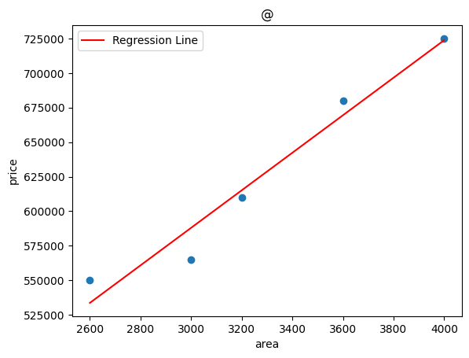

```python
plt.scatter(data.area, data.price)
plt.xlabel('area')
plt.ylabel('price')
plt.title('@')
plt.plot(data.area,reg.predict(data[['area']]),color='r', label='Regression Line')
plt.legend()
plt.show()
```

```python
income_canada = pd.DataFrame({
    'year': [1970,
1971,1972,1973,1974,1975,
1976,
1977,
1978,
1979,
1980,
1981,
1982,
1983,1984,
1985,

1986,
1987,
1988,
1989,
1990,
1991,
1992,
1993,
1994,
1995,
1996,
1997,
1998,
1999,
2000,
2001,
2002,
2003,
2004,
2005,
2006,
2007,
2008,
2009,
2010,
2011,
2012,
2013,
2014,
2015,
2016],
    'income':[
3399.299037,
3768.297935,
4251.175484,
4804.463248,
5576.514583,
5998.144346,
7062.131392,
7100.12617,
7247.967035,
7602.912681,
8355.96812,
9434.390652,
9619.438377,
10416.53659,
10790.32872,
11018.95585,
11482.89153,
12974.80662,
15080.28345,
16426.72548,
16838.6732,
17266.09769,
16412.08309,
15875.58673,
15755.82027,
16369.31725,
16699.82668,
17310.75775,
16622.67187,
17581.02414,
18987.38241,
18601.39724,
19232.17556,
22739.42628,
25719.14715,
29198.05569,
32738.2629,
36144.48122,
37446.48609,
32755.17682,
38420.52289,
42334.71121,
42665.25597,
42676.46837,
41039.8936,
35175.18898,
34229.19363]
})
income_canada.head(10)
```

|  | year | income |
| --- | --- | --- |
| 0 | 1970 | 3399.299037 |
| 1 | 1971 | 3768.297935 |
| 2 | 1972 | 4251.175484 |
| 3 | 1973 | 4804.463248 |
| 4 | 1974 | 5576.514583 |
| 5 | 1975 | 5998.144346 |
| 6 | 1976 | 7062.131392 |
| 7 | 1977 | 7100.126170 |
| 8 | 1978 | 7247.967035 |
| 9 | 1979 | 7602.912681 |

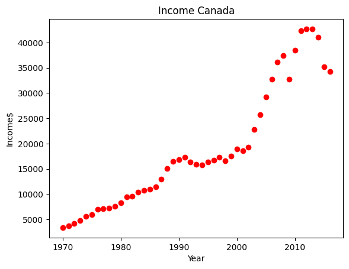

```python
plt.scatter(income_canada.year, income_canada.income, color = 'red')
plt.xlabel('Year')
plt.ylabel('Income$')
plt.title('Income Canada')
plt.show()
```

```python
regression = linear_model.LinearRegression()
regression.fit(income_canada[['year']], income_canada.income)
```

```
LinearRegression()
```

```python
prediction_2020 = regression.predict([[2020]])

print(f"Predicted income for 2020: ${prediction_2020[0]:,.2f}")
```

```
Predicted income for 2020: $41,288.69
```

```python
regression.coef_
```

```
array([828.46507522])
```

```python
regression.intercept_
```

```
-1632210.7578554575
```

### m*x+b,(m=coef, b=intercept)

```python
828.46507522*2020-1632210.7578554575
```

```
41288.694088942604
```

### Predict income in 2024

```python
prediction_2020 = regression.predict([[2024]])

print(f"Predicted income for 2024: ${prediction_2020[0]:,.2f}")
```

```
Predicted income for 2024: $44,602.55
```

```python
hp = pd.DataFrame({'area': [2600,3000,3200,3600,4000],
                     'bedrooms': [3,4,3,3,5],
                     'age':[20,15,18,30,8],
       'price': [550000, 565000,610000,595000,760000]
       })
hp
```

|  | area | bedrooms | age | price |
| --- | --- | --- | --- | --- |
| 0 | 2600 | 3 | 20 | 550000 |
| 1 | 3000 | 4 | 15 | 565000 |
| 2 | 3200 | 3 | 18 | 610000 |
| 3 | 3600 | 3 | 30 | 595000 |
| 4 | 4000 | 5 | 8 | 760000 |

```python
import math
```

```python
median_bedrooms = math.floor(hp.bedrooms.median())
median_bedrooms
```

```
3
```

reg_1 = linear_model.LinearRegression(): This creates a new instance of the linear regression model.

reg_1.fit(hp[['area','bedrooms','age']], hp.price): This fits the model using the hp DataFrame.

hp[['area', 'bedrooms', 'age']]: These are the independent variables (features) used for prediction: house size (area), number of bedrooms (bedrooms), and house age (age).

hp.price: This is the dependent variable (target) that the model will try to predict: house price (price).

```python
reg_1 = linear_model.LinearRegression()
reg_1.fit(hp[['area','bedrooms','age']],hp.price)
```

```
LinearRegression()
```

# coef_:m, mx+b

```python
reg_1.coef_
```

```
array([   137.25, -26025.  ,  -6825.  ])
```

# intercept:b

```python
reg_1.intercept_
```

```
383724.9999999998
```

```python
prediction_price = reg_1.predict([[3000,3,40]])

print(f"Predicted price: ${prediction_price[0]:,.2f}")
```

```
Predicted price: $444,400.00
```

```python
137.25*3000+-26025*3+-6825*40+383724.9999999998
```

```
444399.9999999998
```

```python
prediction_price_1= reg_1.predict([[2500,4,5]])

print(f'Predicted Price: ${prediction_price_1[0]:,.2f}')
```

```
Predicted Price: $588,625.00
```

```python
hi_sal = pd.DataFrame({
    'experience':[0,0,5,2,7,3,10,11],
    'test_score':[8,8,6,10,9,7,7,7],
    'interview_score':[9,6,7,10,6,10,7,8],
    'salary':[50000,45000,60000,65000,70000,62000,72000,80000]
})
hi_sal
```

|  | experience | test_score | interview_score | salary |
| --- | --- | --- | --- | --- |
| 0 | 0 | 8 | 9 | 50000 |
| 1 | 0 | 8 | 6 | 45000 |
| 2 | 5 | 6 | 7 | 60000 |
| 3 | 2 | 10 | 10 | 65000 |
| 4 | 7 | 9 | 6 | 70000 |
| 5 | 3 | 7 | 10 | 62000 |
| 6 | 10 | 7 | 7 | 72000 |
| 7 | 11 | 7 | 8 | 80000 |

```python
import math
median_test_score = math.floor(hi_sal['test_score'].mean())
median_test_score
```

```
7
```

### Fit the Model

```python
reg_2 = linear_model.LinearRegression()
reg_2.fit(hi_sal[['experience','test_score','interview_score']], hi_sal.salary)
```

```
LinearRegression()
```

2 years of experience

Test score of 9

Interview score of 6

```python
predicted_salary = reg_2.predict([[2,9,6]])

print(f'Predicted Salary: ${predicted_salary[0]:,.2f}')
```

```
Predicted Salary: $53,713.87
```

# m, mx+b

```python
reg_2.coef_
```

```
array([2922.26901502, 2221.30909959, 2147.48256637])
```

# b, mx+b

```python
reg_2.intercept_
```

```
14992.65144669314
```

(mx+mx+mx)+b

```python
2922.26901502*2+2221.30909959*9+2147.48256637*6+14992.65144669314
```

```
53713.86677126314
```

```python
predicted_salary_1 = reg_2.predict([[12,10,10]])

print(f'Predicted Salary: ${predicted_salary_1[0]:,.2f}')
```

```
Predicted Salary: $93,747.80
```

```python
2922.26901502*12+2221.30909959*10+2147.48256637*10+14992.65144669314
```

```
93747.79628653315
```